# TSA - RBOB

Author

Connor Beebe, Luke Talman and Olivier Haley

Published

January 20, 2024

##### What it is RBOB and why does it matter?

- Reformulated Blendstock for Oxygenate Blending (RBOB) is a product derived from Crude Oil. It is intended for blending with oxygenates in order to attain a finished reformulated gasoline.
- Before becoming market ready, gasoline is transported as RBOB or Conventional Blendstock of Oxygenate Blending (CBOB). RBOB is more common in places with higher environmental restrictions.
- RBOB + 10% Ethanol + Additives = Marketable Gasoline
- RBOB futures are used by traders to profit from or hedge their exposure to price changes.
- The RBOB futures market is based in NY Harbor, an area with regulations requiring reformulated gasoline.

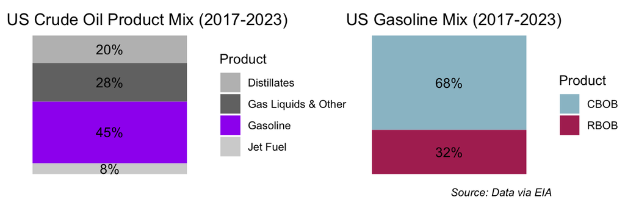

#### Production Process

- Crude oil input:
- Separated into fractions based upon boiling point
- Gasoline blending components are lighter weight with a lower boiling point
- Once separated, gasoline components go through additional processing to create gasoline blends, including RBOB
- Blends have varying characteristics, such as Octane level, chemical composition, and vapor pressure rating, per regulation and seasonal requirements

[figure not shown]

#### Consumption

- Consumer and industrial behavior influence demand
- Downstream companies also influence demand when managing production shortfalls or inventory surplus
  - Ex. Refinery needing to fulfill obligations after an unexpected shutdown
- Local gas specifications impact regional RBOB stock levels

[figure not shown]

RBOB Trading Specs

[output not shown]

Source: Nymex Rulebook, Chapter 191

## Summary

### New Trades if any

- October 25, 2023
  - Long December RBOB cx, Short February RBOB cx
  - Position Size: 200,000 bbl
  - Closed on November 6, 2023
- November 10, 2023
  - Long January RBOB cx
  - Position size: 100,000 bbl
  - Closed Nov 22, 2023 (end of game)
- November 10, 2023
  - Long Dec/March RBOB Spread
  - Position size: 150,000 bbl
  - Closed November 17
- November 17, 2023:
  - Long Dec 2023 RBOB 6,300,000 gal
  - Short March 2024 RBOB 3,696,000 gal
  - Closed Nov 22, 2023 (end of game)

#### Methodology

We are making trading decisions based upon **Gasoline Supply/Demand** changes.

- RBOB is used by traders to hedge against Gasoline exposure
- Availability of timely and accurate data
- High Correlation between RBOB futures and Gasoline prices

[interactive chart not shown]

#### Supply Forecast Indicators

- Crude Supply
  - Declining crack spreads translate to lower refinery earnings and potential losses (rising crude price).
  - Refineries typically lower output at the end of driving season (summer).
- Crude Crack Spread
  - WTI and RBOB moving inversely
  - Small Crack Spread -> Profit Margins for refining Crude into products like Gasoline is limited

#### Demand Forecast Indicators

- Miles Driven
- Population
- Disposable Income

### Forcast

- Note: Forcast updates daily and does not necessarily represent the decisions made at a given time.

[interactive chart not shown]

## Trades

### Trade 1

#### Market View

- Gasoline demand has came out lower than expected in the past few weeks. Crude storages are higher than anticipated.
- RBOB has taken a bigger hit than Crude, dropping the Crack Spread to yearly lows. Dec/March cx time spread is trading at decade lows.
- We believe the market is over reacting to the short term bad news. Supply/demand balances will become more favorable for refineries in the short term, reducing the spread between the RBOB crack in December relative to February.
- Storage Levels, see Exhibits 3

#### Risk Appetite & Desired Exposure

- We are trading spreads, not the flat price
- We are confident in our market call and see little downside risk.

#### Execution & Monetization Strategies

- We are betting on the profitability of gasoline refining to increase in the short term.
- Long Dec 2023 RBOB Crack Spread
- Short Feb 2024 RBOB Crack Spread
- Indicators to look out for:
  - Bull: Increase in demand relative to supply
  - Bear: Increase in gasoline stocks in the short term.

#### Decisions

[interactive chart not shown]

### Trade 2

#### Market View

- Bullish on the RBOB Crack Spread in the short term
- Implied storage expected to remain relatively constant, with slight draws
- The expectation of contributed stabilization of storage level combined with relatively low crude prices suggests that the relatively small crack spread, when compared to previous years, will move in a mean-reverting direction in the near term

##### Risk Appetite & Desired Exposure

- Moderate risk without taking RBOB flat price exposure
- We wanted to limit price swings approximately +/- 150k per day; thus, we selected 100k BBL as our position size, per recent daily P&L swings.

##### Execution & Monetization Strategies

- Long January 2024 RBOB contracts and short January 2024 WTI contracts, giving us a long position on the January RBOB Crack Spread

[interactive chart not shown]

### Trade 3

#### Market View

- Our supply & demand model in the short term is forcasting small storage draws. RBOB prices have recently taken a bit of a hit, which can be attributable to the time of the year and speculative fears surrounding world events. This is pictured in our supply & demand curve showing a stint of implied storage fills before entering our position. We believe the price was driven below our perceived market value by speculative fears in the short term. We are Bullish in the near term.

#### Risk Appetite & Desired Exposure

- Moderate to low risk, with some hedged exposure. See exhibit 6 and note that daily PL generally hovers between 0.5 and -0.5. We chose this spread to limit our daily PL to 150,000.

#### Execution & Monetization Strategies

- Long the Front contract (Dec), short the 4th contract (Mar) time spread. This was put in place to expose us to any price increases from implied storage draws while using the term structure to hedge some of the volatility.

[interactive chart not shown]

#### Trade 3b

Upon learning about how to implement hedge ratios, we wanted to correctly hedge our time spread position to maximize profit. Below shows the contract betas as they progress further into the future:

[interactive chart not shown]

#### Dec/March Hedge ratio

- New hedge ratio for Dec/March RBOB Spread: 0.5938231
- We then closed our position and reopened with the correct ratio in accordance with the calculations above.
- New Exposure

[interactive chart not shown]

#### Total P/L

[interactive chart not shown]

## Conclusion

### Lessons Learned

What have you learned from this project?

- The complexity of gasoline was a big learning curve for us. The different blends and blending components sent us down a rabbit hole of research. After tirelessly attempting to construct a supply & demand balance for RBOB by combining the different components and their relative import/export data, we cut our losses and opted to go with total finished gasoline to perform our market analysis.
- In recognizing the limitations of our model and its ability to mirror the economics of RBOB itself, we were uneasy with taking on a lot of risk solely based on our SD model.
- Limited Public news. We learned that commodities like RBOB have very few public and timely news sources, pushing us to really dig for news and reflect to draw our own conclusions, rather than having a clear market status delivered to us.
- Trading on a weekly time horizon highlights the importance of timing your entries and exits correctly. There are no days off in the trading world.

## Exhibits

### Exhibit 1

#### Supply Indicators

- Supply + Imports + Bio fuels + Adjustments

#### Demand Indicators

- Disposition + Exports

### Exhibit 2

HO cx vs RBOB cx

[interactive chart not shown]

### Exhibit 3

#### Trade 1 Storage Visualization

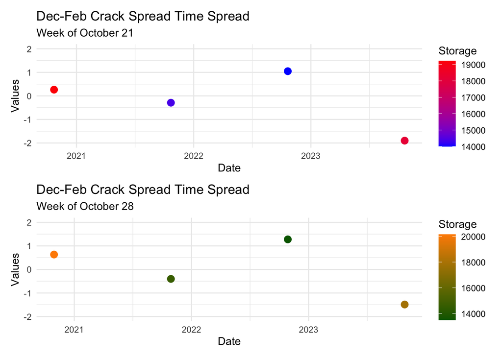

### Exhibit 4

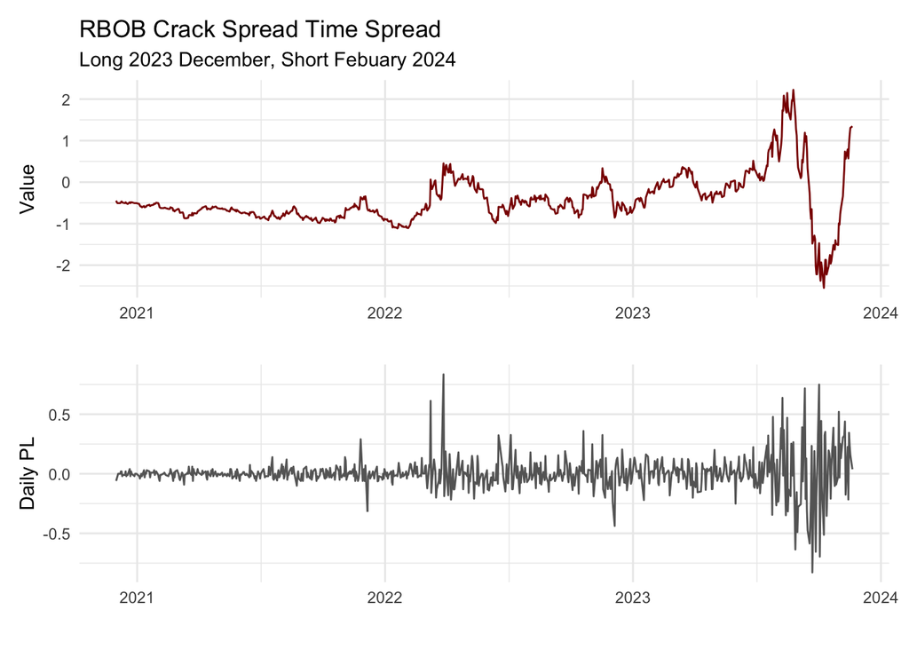

### Exhibit 5

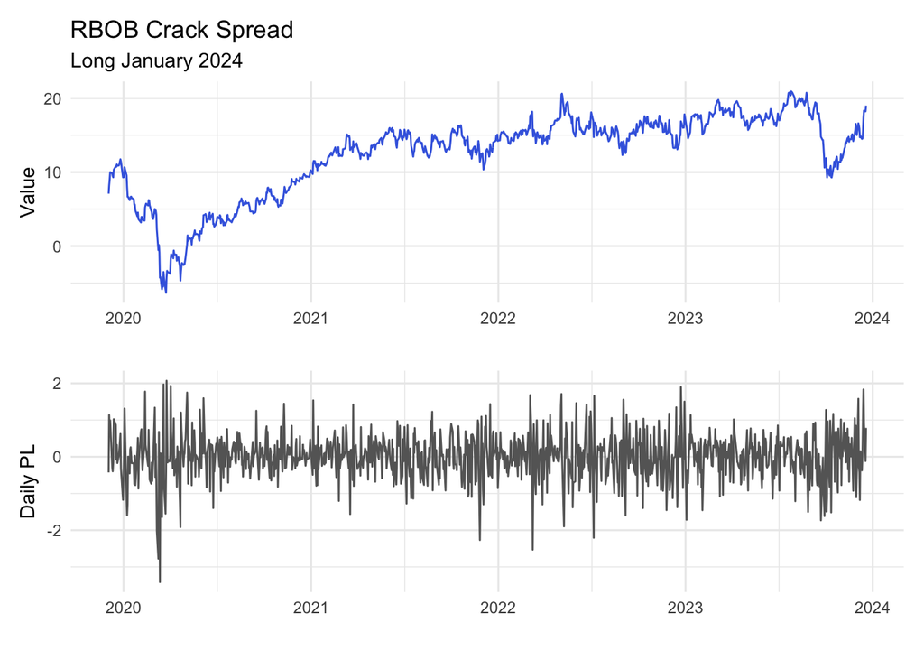

### Exhibit 6

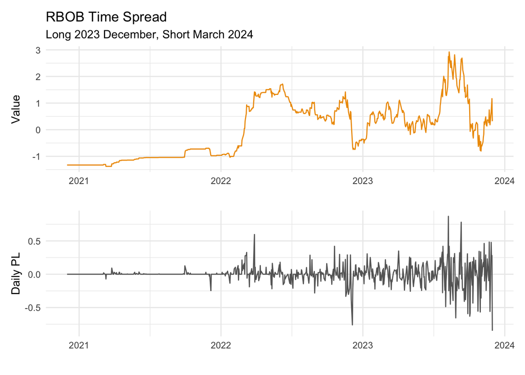

### Exhibit 7

[interactive chart not shown]